# IRTlib – inlinehelp_view_study_routing_de-deu

### Spezialfall: *prüfe*-Operator für drei Bedingungen

Für drei Bedingungen stellt der *Blockly*-Editor eine speziellen Operator *prüfe-falls wahr-falls falsch* zur Verfügung:

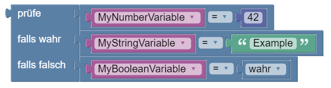

Das Konstrukt ist eine Kurzform für folgende Prüfung, wie sie in folgender Tabelle dargestellt ist:

| MyNumberVariable | MyStringVariable | MyBooleanVariable | Ergebnis |
| --- | --- | --- | --- |
| $= 42$ | $=$ Example | (any) | true |
| $= 42$ | $≠$ Example | (any) | false |
| $≠ 42$ | (any) | true | true |
| $≠ 42$ | (any) | false | false |

Ohne den Operator für drei Bedingungen könnte die gleiche Prüfung mit folgender Kombination umgesetzt werden:

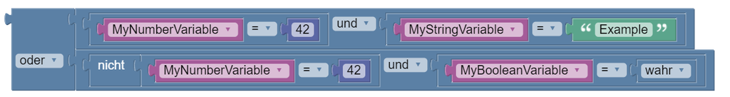

@SD / TODO: Habe ich das richtig interpretiert?

#### Negation

(nach oben)

### Ablaufsteuerung mit Schleifen

Die mehrfache Ausführung von *Blockly*-Operatoren (und der damit darstellbaren Aktionen) ist mit Schleifen möglich. Der Abschnitt *Loops* der *Palette* enthält die dafür notwendigen *Blockly*-Elemente.

#### Wiederhole n-mal

Der folgende *Blockly*-Operator kann verwendet werden, um die Ausführung von Blöcke n-mal zu wiederholen:

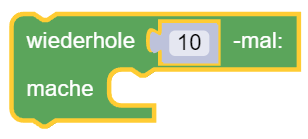

#### Wiederhole solange

Schleifen können auch solange wiederholt werden *bis* eine Bedingung zutrifft (oder *solange* eine Bedingung zutrift):

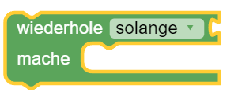

- Beispiel:

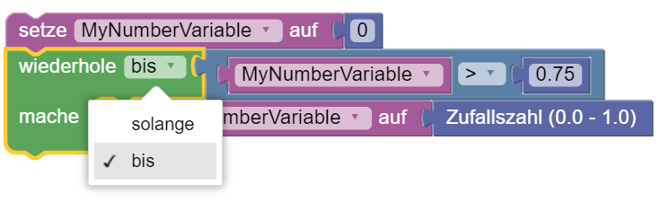

#### Zähle von/bis

Schleife mit Hilfsvariablen:

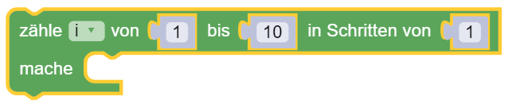

#### Für jeden Wert aus Liste

Schleife über alle Werte einer Liste

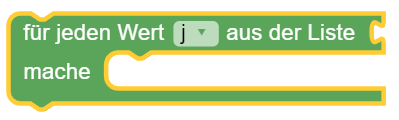

#### Schleifen vorzeitig abbrechen

Folgendes *Blockly*-Element kann genutzt werden, um eine Schleife (vorzeitig) abzubrechen oder um vorzeitig mit dem nächsten Schleifendurchlauf zu beginnen:

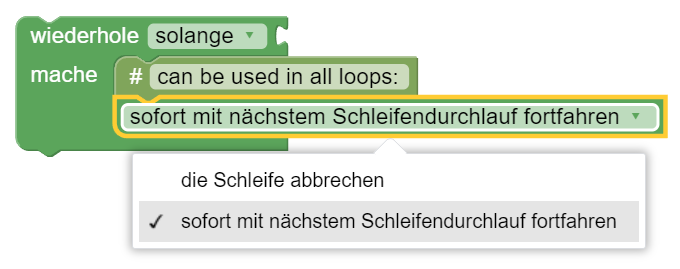

(nach oben)

### Operatoren für Zahlen und einfache mathematische Funktionen

Der Abschnitt *Math* der *Palette* enthält *Blockly*-Elemente zur Verwendung von Zahlen und einfachen mathematischen Funktionen.

#### Basale Funktionen

- Addition, Subtraktion, Multiplikation, Division und Potenzfunktion von zwei Argumenten:

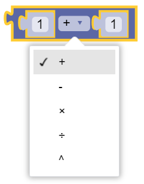

- Schachtelung ist möglich, z.B.:

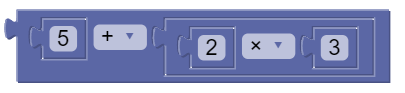

- Division mit Rest:

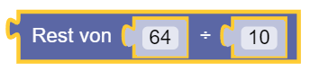

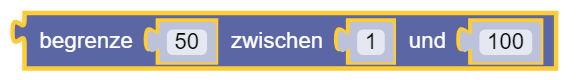

#### Eingebaute Funktionen

- Trigonometrische Funktionen:

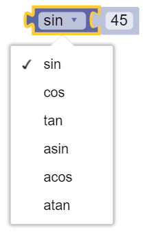

- Runden von Werten:

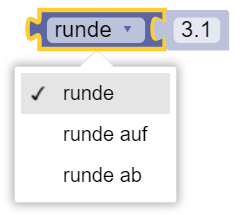

- Weitere Funktionen:

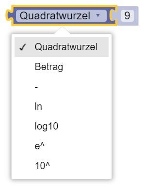

@SD / TODO: Was ist “-”?

#### Erzeugung von Zufallszahlen

- Ganzzahlen (in Wertebereich):

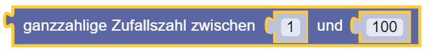

#### Numerische Funktionen für Listen

Vordefinierte Funktionen für Listen umfassen:

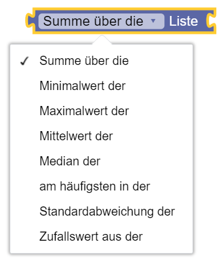

Hinweise:

- Weitere Funktionen lassen sich, wenn benötigt, mit Schleifen für Listen umsetzen.
- Bei der Verwendung der Funktionen ist darauf zu achten, dass die ausgewählte Funktion für die Datentypen der List anwendbar ist.

@SD / TODO: Was passiert, wenn man die Funktionen auf Listen mit “Tasks” anwendet?

(nach oben)

### Operatoren für Text und einfache String-Operationen

Der Abschnitt *Text* der *Palette* enthält *Blockly*-Elemente zur Verwendung Zeichenketten.

#### Verketten

Verschiedene Operatoren können verwendet werden, um Text zusammenzufügen und zu Variablen zuzuweisen:

- Einen Text an eine Variable anfügen:

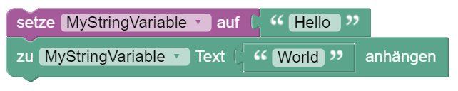

- Texte (und Variablenwerte) verketten und an andere *Blockly*-Operatoren weitergeben:

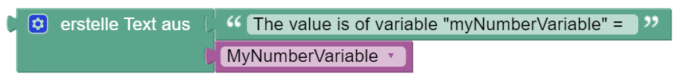

- Zusammengefügten Texte eine Variable zuweisen:

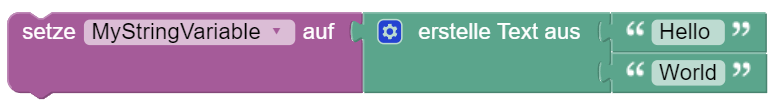

#### Textlänge

Die Länge einer Zeichenkette kann mit folgendem *Blockly*-Operator ermittelt werden:

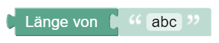

#### Prüfung auf leeren String

Leere String-Variablen können daran erkannt werden, dass die Anzahl der Zeichen $0$ ist.

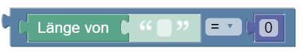

#### Position in String finden

Ein Operator, der *im Text* (der per Variable oder als Ausdruck übergeben wird) das *erste* oder *letzte* *Auftreten eines Begriffs* sucht, kann wie folgt verwendet werden:

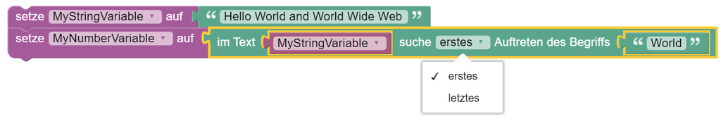

Zurückgegben wird dabei die Position des *Begriffs* innerhalb der Zeichenkette (d.h. *im Text*).

@SD / TODO: Richtig?

#### Teilzeichenketten bilden

Der folgende Operator nimmt aus der übergebenen Zeichenkette *im Text* die ersten Buchstaben. Die Anzahl der Buchstaben wird dabei ebenfalls übergeben.

- Beispiel (hier wird, wenn die Option *nimm ersten* ausgewählt ist der Variable `MyStringVariable` der Text `ABC`, d.h. die ersten drei Buchstaben der Zeichenkette `ABCDEFG`) zugewiesen:

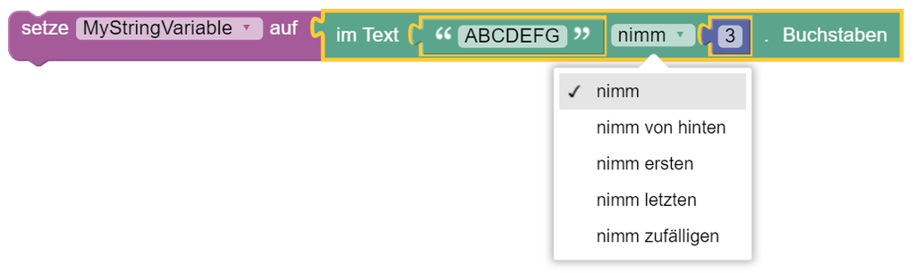

@SD / TODO: Was ist der Unterschied zwischen ‘nimm’ und ‘nimm ersten’ bzw. ‘nimm von hinten’ und ‘nimm letzten’?

Buchstaben aus einer Zeichenkette kann man auch mit folgendem Operator entnehmen, und bspw. einer Variablen zuweisen:

- Beispiel (hier können bspw. die Zeichen 3 bis 5 aus einer Zeichenkette entnommen werden):

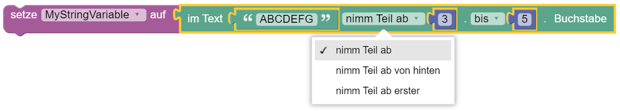

@SD / TODO: Was ist ‘nimm Teil ab erster’?

#### Texts Verändern

Vorhandene Texte (entweder als Ausdrücke oder aus Variablen vom *Datentyp* *String*) können durch die Anwendung von Operatoren verändert werden.

- Folgender Operator kann verwendet werden, um Text in Grossbuchstaben oder in Kleinbuchstaben umzuwandeln:

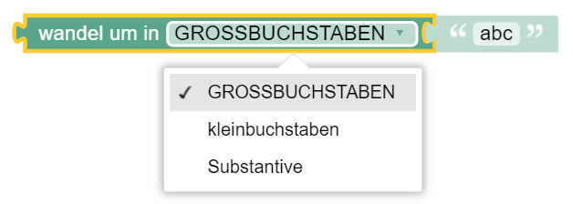

@SD / TODO: Was macht die Option ‘Substantive’?

- Führende, abschließende oder führende und abschließende Leerzeichen können durch folgenden Operator entfernt werden:

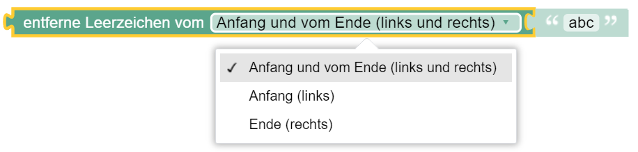

(nach oben)

### Operatoren für Zeiten und einfache Zeit-Operationen

Der Abschnitt *Date & Time* der *Palette* enthält *Blockly*-Elemente zur Verwendung Zeiten innerhalb von Ablaufdefinitionen.

#### Festhalten von Zeitpunkten

@SD / TODO:

#### Ermitteln von Zeitdifferenzen

Vollständiges Beispiel: Folgender *Blockly*-Code misst die Zeit für die Bearbeitung von Task 1 bis 4. Dafür wird zunächst der Startzeitpunkt fegesthalten, und nach der Bearbeitung der Aufgaben wird die Zeitdifferenz ermittelt und in Sekunden umgewandelt:

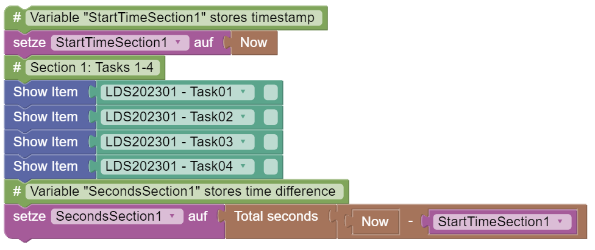

#### Umrechen von Zeitmaßen

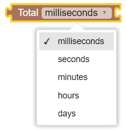

@SD / TODO: Der “Total Sceonds” Operator hat früher (d.h. auf https://blockly.software-driven.de/) erlaubt, die Einheit mit anzugeben (also Milliseconds, Seconds, Minutes etc., vgl. Bild was von der alten Implementierung stammt). Gab es einen bestimmten Grund das zu entfernen oder kommt das noch?

(nach oben)

### Operatoren für Listen

Der Abschnitt *Lists* der *Palette* enthält *Blockly*-Elemente zur Erstellung und Verwendung von Listen.

#### Liste erstellen

Liste können aus besehenden Elementen erstellt werden:

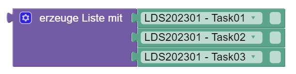

Die Anzahl der Elemente des Operators *erzeuge Liste mit* kann per Drag-and-Drop konfiguriert werden, nachdem Zahnrad-Symbol angeklickt wurde:

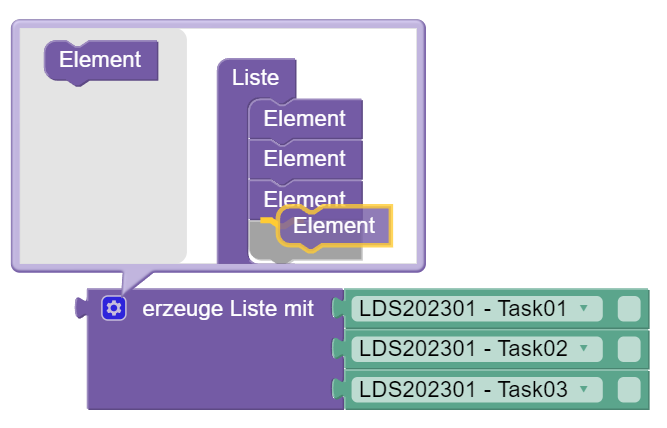

@SD / TODO: Aus welchen Elementen kann man Listen erstellen?

#### Listen Sortieren

@SD / TODO: Hier wäre vielleicht noch eine Option sinnvoll, Listen zufällig zu sortieren (als zu Mischen). Dann könnte man, in den Fällen wo man Items in einer beliebigen Reihenfolge braucht das direkt umsetzen.

(nach oben)

### *Blockly*-Variablen

Der Abschnitt *Variables* der *Palette* enthält *Blockly*-Elemente zur Erstellung und Verwendung von Variablen. Variablen können über die Schaltfläche *Typisierte Variable erstellen* angelegt werden:

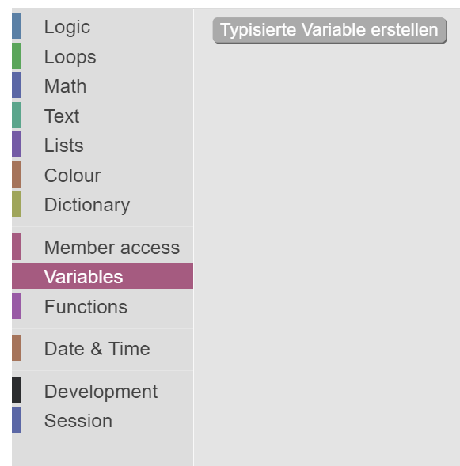

*Blockly*-Variablen haben immer einen *Variablennamen* und einen *Datentyp*:

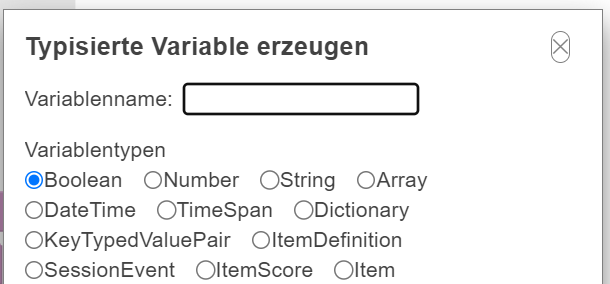

@SD / TODO: Wie kann man auf Parameter zugreifen im Blockly? Einfach eine Variable anlegen, die einem Parameter entspricht? Oder sollen die Parameter künftig automatisch im Blockly-Editor angelegt werden?

#### Einfache Datentypen und Wertzuweisungen

Folgende basale Datentypen werden unterstützt:

- *Boolean*: Logische Wahrheitswerte und Logische Ausdrücke (`wahr` oder `falsch`)

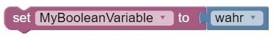

- *Number*: Datentyp für Zahlenwerte (mit und ohne Dezimalstelle)

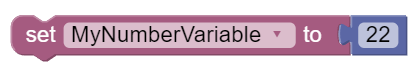

- *String*: Textwerte bzw. Zeichenketten

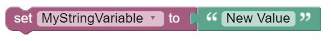

Für Zeiten werden folgende Datentypen bereitgestellt:

- *DateTime*: Datum und Uhrzeit

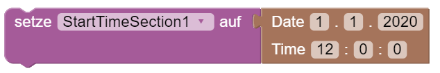

@SD / TODO: Für Zeitspannen hätte ich gern auch Millisekunden, ggf. könnte man dann hier auch noch einen Setter mit MS haben wollen?

- *TimeSpan*: Zeitspanne

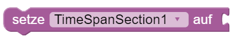

@SD / TODO: Für Zeitspannen weiß ich nicht, wie ich den Wert zuweisen soll (außer über die Differenz von zwei DateTimes.

#### Datentypen für mehrere Werte

Datentypen für mehrere Elemente:

- *Array*: Datentyp für Listen

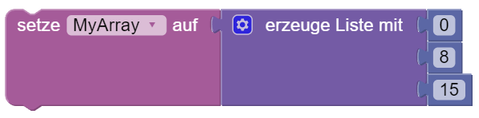

- *Dictionary*:

@SD / TODO: Hier braucht es noch ein Beispiel / mehr Erklärung.

- *KeyTypedValuePairs*:

@SD / TODO: Hier braucht es noch ein Beispiel / mehr Erklärung.

@SD / TODO: Welche weitere Erklärung braucht es für ItemDefinition, SessionEvent, ItemScore, Item(s)… ?

#### Variablenwerte Verwenden

Für die Verwendung von Variablenwerten, können *Blockly*-Elemente mit *Eingängen* folgende Komponente aufnehmen:

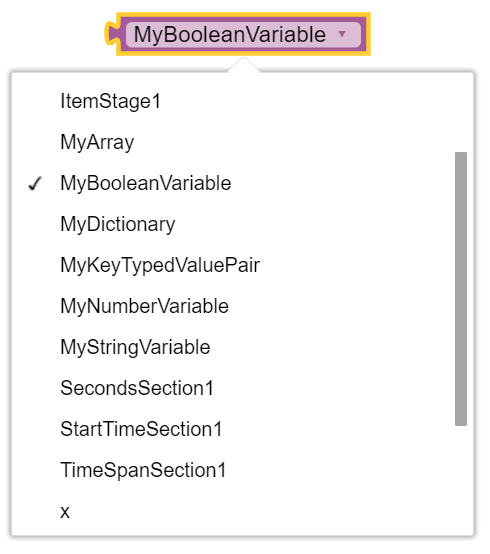

Welche Variable verwendet wird, kann dabei ausgewählt werden. Für defnierte Variablen findet sich dafür jeweils auch ein *Blockly*-Element im Abschnitt *Variables* der *Palette*:

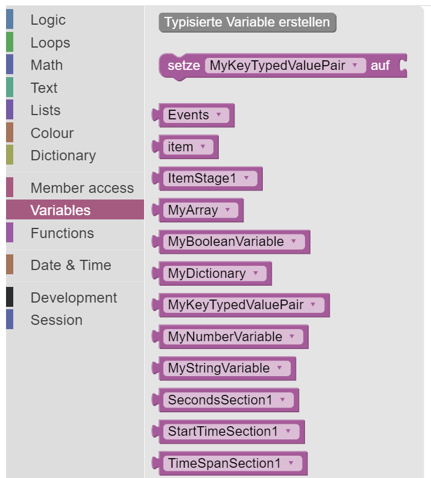

In der Palette findet sich auch ein *Blockly*-Element vom Typ *setze … auf*. In diesem kann ebenfalls ausgewählt werden, den Wert welcher Variable es setzt:

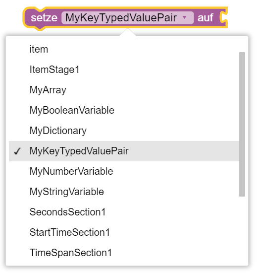

(nach oben)

### *Blockly*-Funktionen

Der Abschnitt *Functions* der *Palette* enthält *Blockly*-Elemente zur Verwendung von Funktionen innerhalb von Ablaufdefinitionen. Funktionen kombinieren *Blocky*-Code, so dass dieser nur einmal definiert aber mehrfach verwendet werden kann.

#### Definieren von Funktionen

Es können zwei verschiede Formen von Funktionen definiert werden.

- Funktionen ohne Rückgabewert:

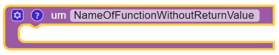

Funktionen ohne Rückgabewert können, damit sie augerufen werden, im Ablauf einfach mit vorherigen und nachfolgenden *Blockly*-Elementen verbunden werden (d.h. sie haben eine Verbindung nach oben und unten):

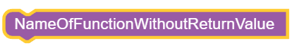

- Funktionen mit Rückgabewert:

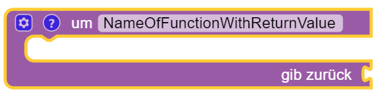

Funktionen mit Rückgabewert können in einem Zuweisungs-Block aufgerufen werden (d.h. sie haben eine Verbindung nach links):

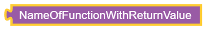

Zu welchem Typ eine Zuweisung sinnvoll ist, hängt von dem Typ des Rückgabewerts ab.

#### Definieren von Rückgabewerten von Funktionen

*Rückgabewerte* können für Funktionen mit Rückgabewert definiert werden. Der Rückgabewert kann direkt an die Funktionsdefinition neben *gib zurück* angefügt werden:

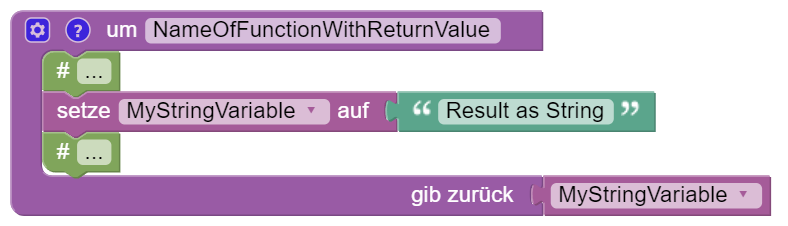

Ergänzend stehen die folgenden zwei *Blockly*-Elemente zur Verfügung, die nur innerhalb einer Funktiondefintion (mit Rückgabewert) verwendet werden können:

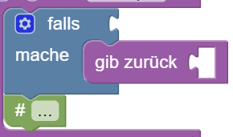

- Beide Operatoren (*falls gibt zurück* und *gib zurück*) können nicht außerhalb von Funktionen verwendet werden:

[figure not shown]

- Die beide Operatoren (*falls gibt zurück* und *gib zurück*) können innerhalb von Funktionen ohne Rückgabewert verwendet werden, um die Abarbeitung von Funktionen zu beenden (aber nicht zum Rückgeben von Werten):

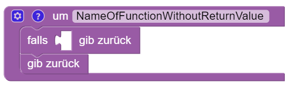

Beispiel:

- Die folgende Funktion gibt den Wert der Variablen `MyStringVariable` (*Any value 1*) in 50% der Fälle zurück (d.h. wenn eine erste gezogene Zufallsvariable größer $0.5$ ist). In den anderen 50% der Fälle, wird eine weitere Zufallsvariable gezogen, und wenn diese größer $0.5$ ist, dann wird der Text *Any value 2* zurückgegeben. Ist auch dies nicht der Fall, dann wird der Text *Default* zurückgebeben:

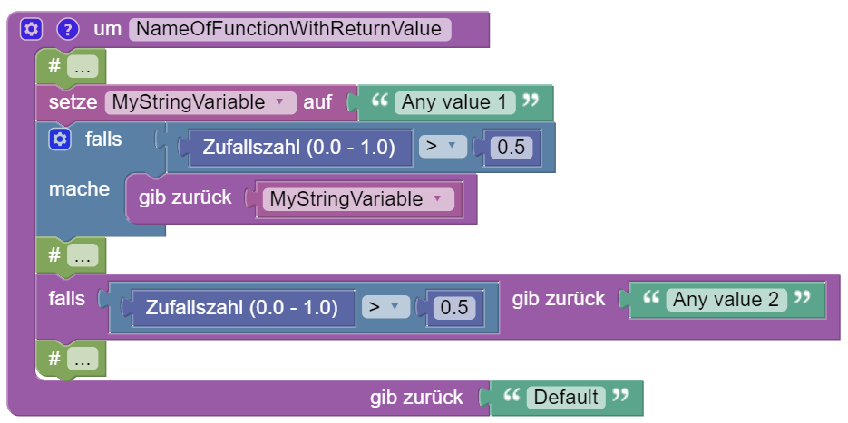

Rückgabewerte sind typisiert. Die Ablaufsteuerung unterstützt auch Funktionen, die …

- … einzelne *Tasks* zurückgeben:

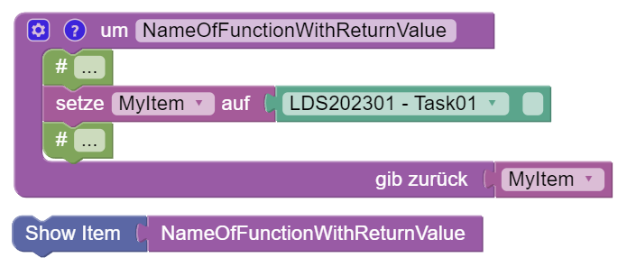

- … Listen von *Tasks* zurückgeben:

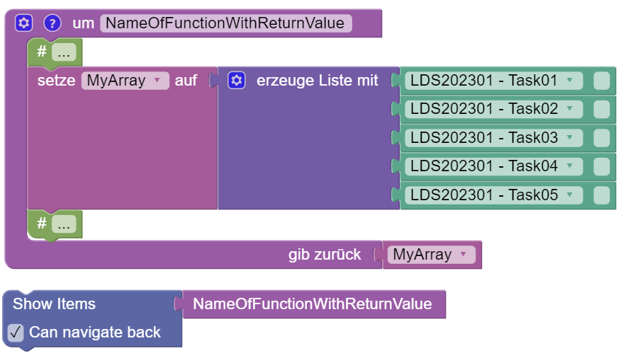

#### Definieren von Aufrufparametern von Funktionen

Funktionen können auch Parameter verwenden, die beim Aufruf der Funktion zu übergeben sind (*Aufrufparametern*). Die Defintion von Aufrufparametern ist nach einem Klick auf das kleine Zahnrad-Symbol eines Funktions-Blocks möglich:

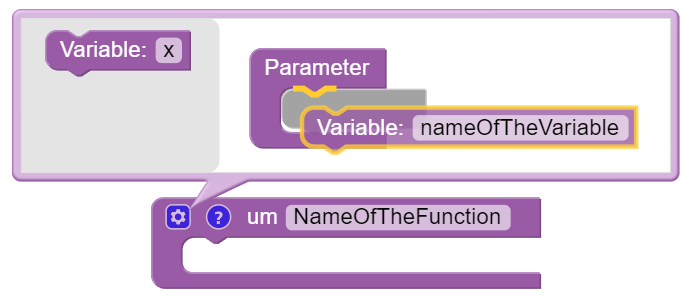

Passend zur Definition der Parameter, erfolgt dann der Aufruf der Funktion durch Übergabe:

- Definition eines Parameters

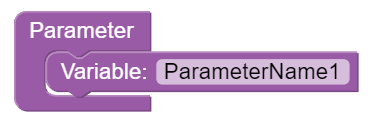

- Aufruf der Funktion mit Angabe von Wert:

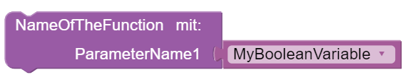

Beispiel:

- Das folgende Beispiel zeigt eine Funktion mit zwei Parameter, deren Verwendung innerhalb der Funktion am Beispiel von Bedingungen und den Aufruf der Funktion mit festen Werten:

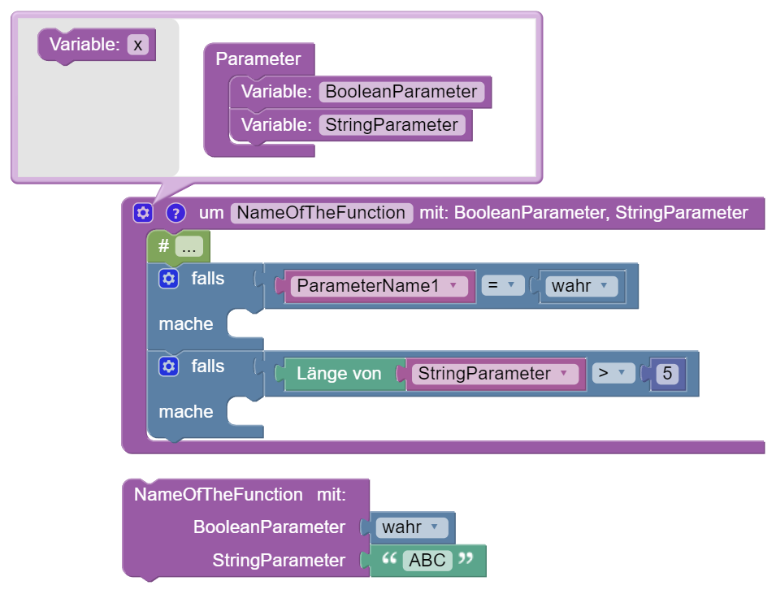

- Alternativ kann die Funktion natürlich auch mit Variablen aufgerufen werden:

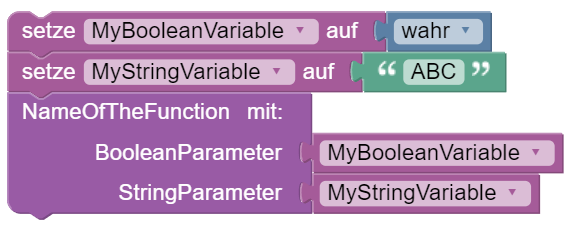

(nach oben)

### Nutzung von Itemergebnissen in der Ablaufsteuerung

(nach oben)

### *Blockly*-Operatoren zum Kodieren fehlender Werte

(nach oben)

### *Blockly*-Operatoren zum schreiben von Daten

#### Log-Daten

Folgender Operator kann genutzt werden, um Informationen direkt in die Log-Daten zu speichern:

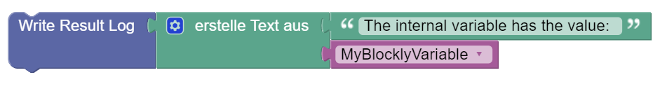

#### Monitoring-Daten

(nach oben)